# Biológia (júlový turnus)

Zpět na rozcestník zpětné vazby | Tento report we Wordu | Data v CSV

## Hodnocení kurzu

Průměrná známka:

| Blok setkání | Průměrná známka |
| --- | --- |
| A | 1.00 |
| B | 1.03 |
| oba | 1.02 |

### Hodnocení po dnech

A a B jsou bloky (A je 9-10:30, B je 11-12:30)

Známky jsou jako ve škole: 1 je nejlepší, 5 nejhorší

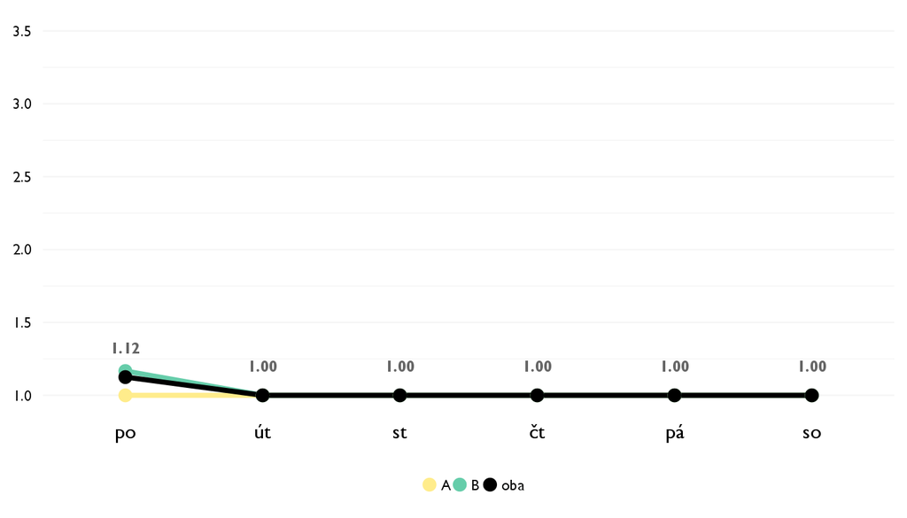

### Co se na kurzu líbilo

- Najviac sa mi páčilo to ako lektorka kurz viedla a jej zápal pre tento odbor. Taktiež sa mi velmi pacilo ,ze nam dokázala dat viac informácii o tom ako prebieha naozajstný výskum a dokázala nam dostatočne vysvetlit rôzne témy ,ktore nas zaujímali.
- Uvoľnená atmosféra ktorá spríjemnila celkový zážitok tohto kurzu. Taktiež sme sa učili o zaujímavých témach.
- To že sme prechádzalikaždý deň nejakým experimentom, výskumom a skúsili sme si, ako takí vedcovia fungujú. zároveň sme sa naučili aj dosť teorie. Celkom dosť som si aj zapamatala, kvoli zhrnutiu na konci a záverečnému kvízu.
- Všetko to ako sme sa zapájali a skúšali si veci v praxi.
- Velmi sa mi pacilo ako sme sa mohli zapojovat a ked sme sme isli zbierat vzorky micro organizmov.
- Kurz bol nesmierne putavy a obohacujuci. Velmi dobre sa nam ucilo a dalej sme z toho cerpali a pracovali.
- Páčilo sa mi, že nám Marta ukazovala rozne príklady na dané témy.
- Experimenty a videa

### Co na kurzu změnit

- Nemyslím si, ze by sa malo nieco meniť.
- Možno aby bol viacej všeobecnejší. Totiž väčšinu času sme strávili nad genetikou čo bolo pecka ale rád by som vedel aj niečo viac.
- Nič mi nenapadá
- Nič netreba meniť.
- Nic by som nemenila.
- Nemyslím si, že niečo konkrétne, pretože sme preberali dosť náročné témy, ale predsa ešte nejaké zložitosti /napr. mutácie/ zjednodušiť.
- Nic

## Hodnocení lektora

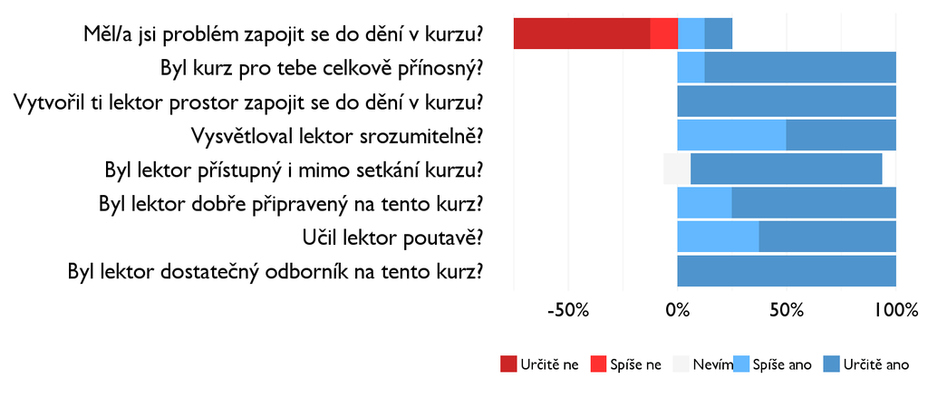

### Komentáře k lektorovi

- Nic.
- Diky moc!

## Náročnost kurzu

### **Jak hodnotíš náročnost…**

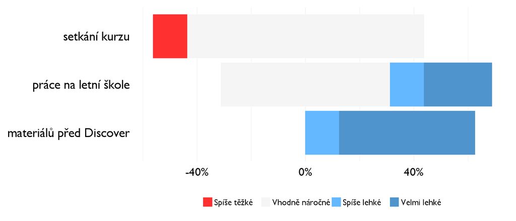

## Didaktika

Na některé otázky jsme se na augustovém turnuse neptali - tam uvidíte nadpis bez grafu.

### Jak lektor učí a měl by to změnit?

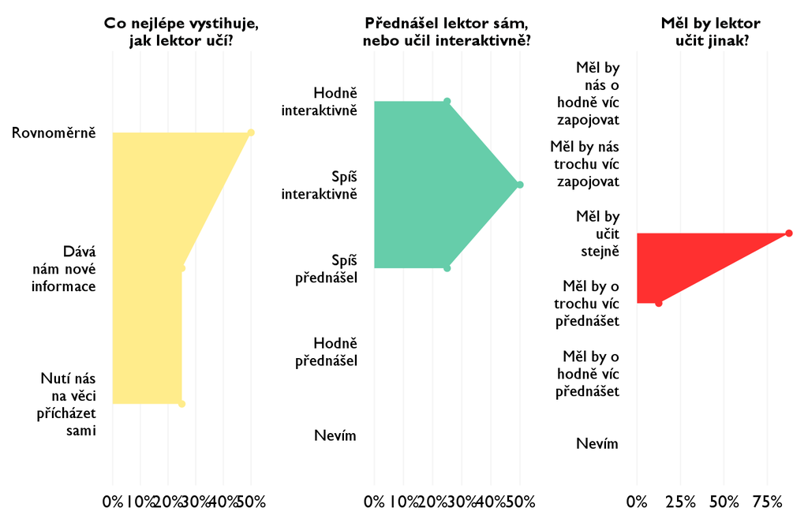

### Jak se studentům nejlépe učí?

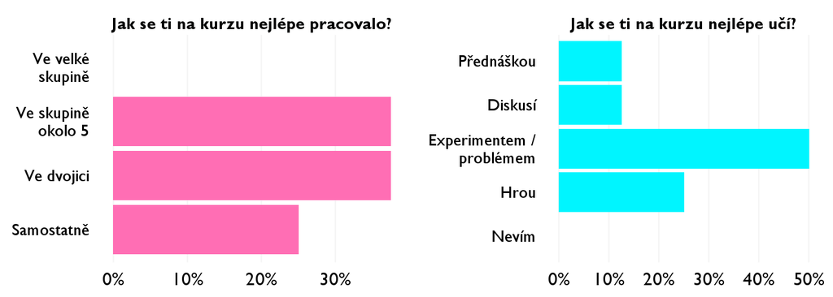

## Ovlivnil tě kurz nějak?

**Pokud ano, jak? Pokud ne, proč ne?**

- Dalo mi to velmi vela nových vedomosti a tym pádom ma to dost obohatilo.
- Naučil ma nové veci.
- Veľmisa mi páčilo, ako sme na veci prichádzali sami, uvedomili si zodpovednosť za svoje rozhodnutia.
- V tom že práca lekára je naozaj náročná a nie každý ju zvládne.
- Utvrdila som si svoje poznatky zo skoly
- Uzastne informacie sme dotali. Posunuli nas dalej. Dakujem.
- Áno, ovplyvnil. Zistila som, že je biológia na mňa náročná.
- Poznala jsem nove moznosti a biologii z jine strany.